# ford-go-bike slides

## Ford Go-Bike Dataset Exploration

## Prepared By: Mohamad AbouElela

```python
# import required liberaries
import numpy as np
import pandas as pd
import matplotlib.pyplot as plt
import seaborn as sb

%matplotlib inline
```

```python
# read dataset file
df = pd.read_csv("fordgobike-feb19.csv")
```

## Exploration Summary

In this Slide deck We will try to explain the Ford Go-Bike dataset findings in summary for easy of understanding by any users. we will focus on:

1. Overall explanation for dataset gender distribution and average gender ages
2. Age and Ride duration relation
3. Most active stations

## Dataset Overview

The dataset represents trips taken by 183412 members of the Ford Go Bike service for month of February of 2019. Data consists of info about trips taken by service's members, their types, their age, their gender, stations of starting and ending trips, duration of trips etc.

## (Visualization 1)

The following Visualization consists of two graphs, the first pie chart represent the gender types of our dataset with percentage of each gender type. The second box plot shows the age quartile distribution of each gender type.

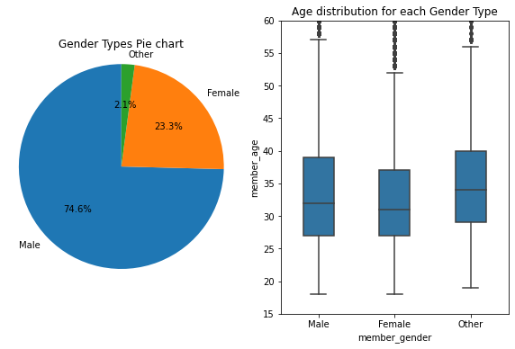

```python
plt.figure(figsize = [10, 6])

plt.subplot(1,2,1)
sorted_gender = df_final['member_gender'].value_counts()
plt.pie(sorted_gender, labels=sorted_gender.index, startangle = 90, autopct = '%1.1f%%')
plt.axis('square')
plt.title('Gender Types Pie chart')

plt.subplot(1,2,2)
sb.boxplot(data = df_final, x = 'member_gender', y = 'member_age', color = base_color, width = 0.4)
plt.ylim((15,60))
plt.title("Age distribution for each Gender Type");
```

## (Visualization 2)

The plot illustrate the relation between Age and Ride duration time in minutes

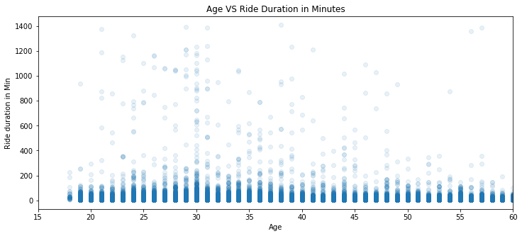

```python
plt.figure(figsize = [12,5])
plt.scatter(x = df_final['member_age'], y = df_final['duration_min'], alpha = 1/10)
plt.xlabel('Age')
plt.ylabel ('Ride duration in Min')
plt.xlim((15,60))
plt.title('Age VS Ride Duration in Minutes');
```

## (Visualization 3)

The plot shows the top ten start station and top ten end stations pf our dataset

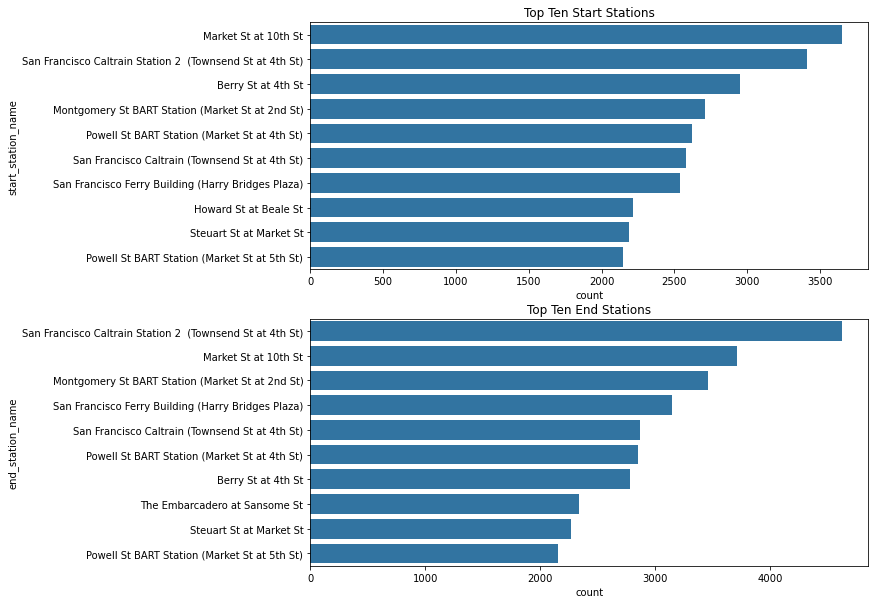

```python
base_color = sb.color_palette()[0]
plt.figure(figsize = [10, 10])
plt.subplot(2,1,1)
start_order = df_final['start_station_name'].value_counts()[:10]
df_start = df_final.loc[df_final['start_station_name'].isin(start_order.index)]
sb.countplot(data = df_start, y = 'start_station_name', order = start_order.index, color = base_color)
plt.title('Top Ten Start Stations')
plt.subplot(2,1,2)
end_order = df_final['end_station_name'].value_counts()[:10]
df_end = df_final.loc[df_final['end_station_name'].isin(end_order.index)]
sb.countplot(data = df_end, y = 'end_station_name', order = end_order.index, color = base_color)
plt.title('Top Ten End Stations');
```